# Practical Session 4

## Help for Task 4.3

Using regression against time is a very simple way to look at the trends and test the slope with the Wald test provided.

For the regression you will need to create a date variable from the year and week (consecutive number of week).

```r
mortz <-
  mortz %>%
  ungroup() %>%
  mutate(Date = seq.int(from = 1, to = nrow(.)))

linregmodel <- glm(
  formula = cases ~ Date,
  family = "poisson",
  data = mortz
)

names(linregmodel)
```

```
##  [1] "coefficients"      "residuals"         "fitted.values"
##  [4] "effects"           "R"                 "rank"
##  [7] "qr"                "family"            "linear.predictors"
## [10] "deviance"          "aic"               "null.deviance"
## [13] "iter"              "weights"           "prior.weights"
## [16] "df.residual"       "df.null"           "y"
## [19] "converged"         "boundary"          "model"
## [22] "call"              "formula"           "terms"
## [25] "data"              "offset"            "control"
## [28] "method"            "contrasts"         "xlevels"
```

Check model results.

```r
summary(linregmodel)
```

```
##
## Call:
## glm(formula = cases ~ Date, family = "poisson", data = mortz)
##
## Coefficients:
##              Estimate Std. Error z value Pr(>|z|)
## (Intercept) 8.407e+00  1.300e-03 6469.40   <2e-16 ***
## Date        1.470e-04  4.282e-06   34.34   <2e-16 ***
## ---
## Signif. codes:  0 '***' 0.001 '**' 0.01 '*' 0.05 '.' 0.1 ' ' 1
##
## (Dispersion parameter for poisson family taken to be 1)
##
##     Null deviance: 32912  on 519  degrees of freedom
## Residual deviance: 31732  on 518  degrees of freedom
## AIC: 37080
##
## Number of Fisher Scoring iterations: 4
```

Variables in R models are specified using notation along the lines of `response_variable ~ explanatory_variable_1 + explanatory_variable_2` etc. A more detailed explanation of how to build model formulas in R can be found in the *Details* section of the help page of the `formula` function: `?stats::formula`.

Identify and interpret the intercept and the trend.

Plot the fitted values against the observed ones.

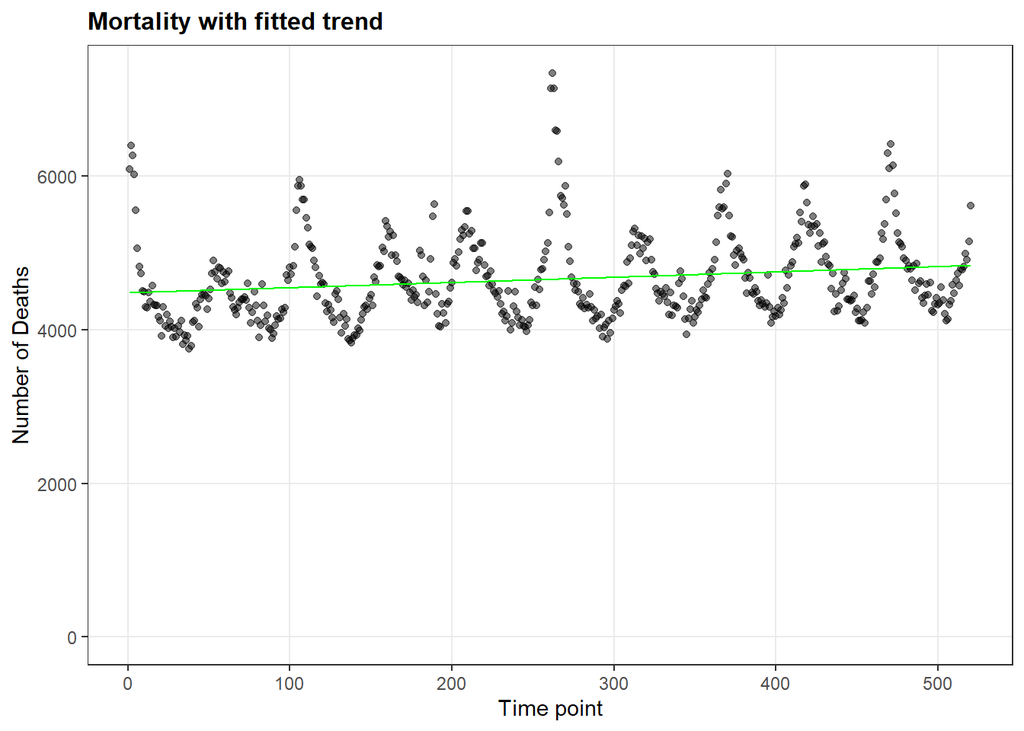

```r
ggplot(data = mortz, mapping = aes(x = Date)) +
  geom_point(mapping = aes(y = cases), alpha = 0.5) +
  geom_line(mapping = aes(y = fitted(linregmodel)), colour = "green") +
  scale_y_continuous(limits = c(0, NA)) +
  labs(x = "Time point", y = "Number of Deaths", title = "Mortality with fitted trend") +
  tsa_theme
```

Could you have used a regression technique other than linear regression? What are the advantages and disadvantages of using linear regression when modelling numbers of cases of a disease?

## Help for Task 4.3.1

```r
# Function to tidy glm regression output
glmtidy <- function(x, caption = "") {
  pander::pander(
    broom::tidy(x,
      exponentiate = TRUE,
      conf.int = TRUE
    ),
    caption = caption
  )
}

# Function to tidy glm regression statistics
glmstats <- function(x) {
  pander::pander(broom::glance(x))
}
```

To take the population into account, we can model it with a Poisson regression (introduced later); first, we need to import the population data provided into the dataset. We will assume the population was steady each year and “jumped” to a new value on January 1<sup>st<sup>.</sup></sup>

```r
mortz <-
  mortz %>%
  mutate(pop = rep(c(
    39953520, 40688520, 41423520, 42196231, 42859172,
    43662613, 44360521, 45236004, 45983169, 46367550
  ),
  each = 52
  ))
```

We have used the `rep` function to repeat each of the population values for each of the 52 weeks in each year.

The “jump” effect has affected the predicted values, too:

```r
mortpoismodel <- glm(cases ~ offset(log(pop)) + Date,
  data = mortz,
  family = "poisson"
)

glmtidy(mortpoismodel)
```

| term | estimate | std.error | statistic | p.value | conf.low | conf.high |
| --- | --- | --- | --- | --- | --- | --- |
| (Intercept) | 0.0001128 | 0.0013 | -6991 | 0 | 0.0001125 | 0.0001131 |
| Date | 0.9998 | 4.285e-06 | -41.17 | 0 | 0.9998 | 0.9998 |

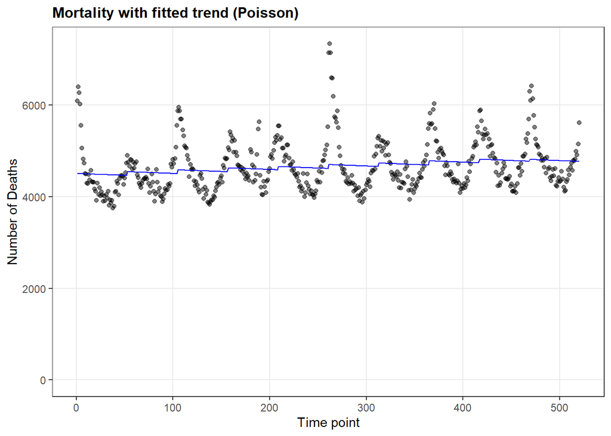

```r
ggplot(data = mortz, mapping = aes(x = Date)) +
  geom_point(mapping = aes(y = cases), alpha = 0.5) +
  geom_line(mapping = aes(y = fitted(mortpoismodel)), colour = "blue") +
  scale_y_continuous(limits = c(0, NA)) +
  labs(
    x = "Time point", y = "Number of Deaths",
    title = "Mortality with fitted trend (Poisson)"
  ) +
  tsa_theme
```

Because of the yearly jump, the overall trend is now negative. Overall, the predicted number of deaths still rises, because the yearly jump is bigger in absolute number than the yearly effect of the negative trend.

## Help for Task 4.3.2

You can use the salmonellosis example (`dis1`) to see how an exponential trend might fit the data better.

```r
source("src/tidyverse/session_4.R")
```

For the regression you will still need to create a date variable from the year and week (weeknumber).

```r
dis1 <- import(here("data", "tsa_practice.xlsx"), which = "dis1")

dis1 <-
  dis1 %>%
  mutate(date = seq.int(from = 1, to = nrow(.)))
```

Generate a new variable `lcases` as the natural logarithm of cases:

```r
salmo <- dis1

salmo <-
  salmo %>%
  mutate(lcases = log(cases))

salmoz2 <-
  salmo %>%
  mutate(date_index = make_yearweek(year = year, week = week)) %>%
  as_tsibble(index = date_index)
```

Plot the logarithm of the number of cases according to the time:

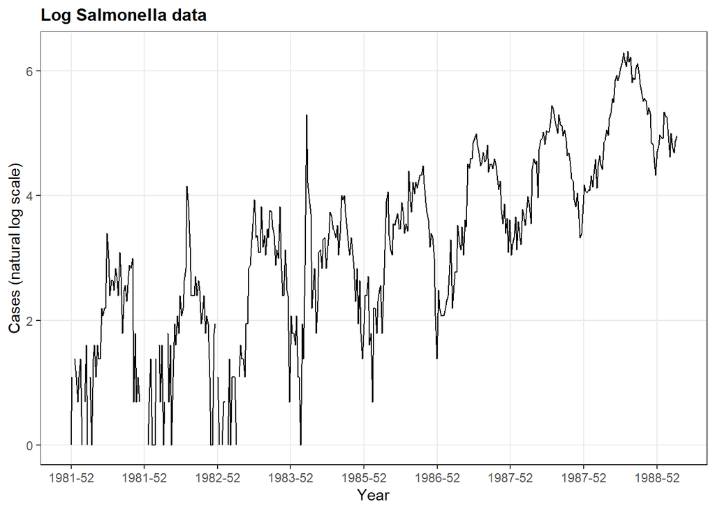

```r
ggplot(data = salmoz2, mapping = aes(x = date_index)) +
  geom_line(mapping = aes(y = lcases)) +
  scale_x_yearweek(date_labels = "%Y-%W", date_breaks = "1 year") +
  scale_y_continuous(limits = c(0, NA)) +
  labs(x = "Year", y = "Cases (natural log scale)", title = "Log Salmonella data") +
  tsa_theme
```

Fit a model of `lcases` against date using linear regression.

```r
logmodel <- lm(lcases ~ date, data = salmoz2)
summary(logmodel)
```

```
##
## Call:
## lm(formula = lcases ~ date, data = salmoz2)
##
## Residuals:
##      Min       1Q   Median       3Q      Max
## -2.65732 -0.61829  0.08907  0.64319  2.60617
##
## Coefficients:
##              Estimate Std. Error t value Pr(>|t|)
## (Intercept) 1.0247934  0.0890767   11.51   <2e-16 ***
## date        0.0099544  0.0003528   28.22   <2e-16 ***
## ---
## Signif. codes:  0 '***' 0.001 '**' 0.01 '*' 0.05 '.' 0.1 ' ' 1
##
## Residual standard error: 0.89 on 417 degrees of freedom
##   (12 observations deleted due to missingness)
## Multiple R-squared:  0.6563, Adjusted R-squared:  0.6555
## F-statistic: 796.2 on 1 and 417 DF,  p-value: < 2.2e-16
```

Plot the log data and the model against time. Note that fitted values cannot be created where the number of cases is missing. Stata seems to do linear interpolation of the fitted values to fill in the gaps, so we will do that too.

```r
fitted_pois_df <-
  enframe(fitted(logmodel), name = "date", value = "ltrend") %>%
  mutate(date = as.integer(date))

salmoz2 <-
  salmoz2 %>%
  left_join(
    x = .,
    y = fitted_pois_df,
    by = "date"
  ) %>%
  mutate(ltrend = imputeTS::na_interpolation(x = ltrend, option = "linear"))
```

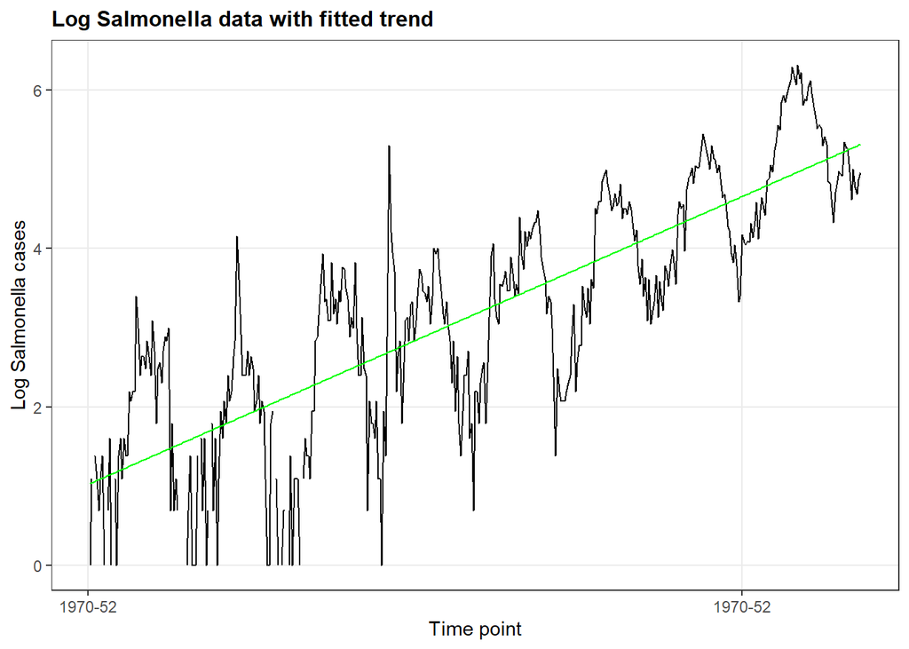

```r
ggplot(data = salmoz2, mapping = aes(x = date)) +
  geom_line(mapping = aes(y = lcases)) +
  geom_line(mapping = aes(y = ltrend), colour = "green") +
  scale_x_yearweek(date_labels = "%Y-%W", date_breaks = "1 year") +
  scale_y_continuous(limits = c(0, NA)) +
  labs(
    x = "Time point",
    y = "Log Salmonella cases",
    title = "Log Salmonella data with fitted trend"
  ) +
  tsa_theme
```

Generate a new variable (`trend`), the anti-log of the prediction (`ltrend`):

```r
salmoz2 <-
  salmoz2 %>%
  mutate(trend = exp(ltrend))
```

Plot the real data (`cases`) and this model (`trend`) according to time:

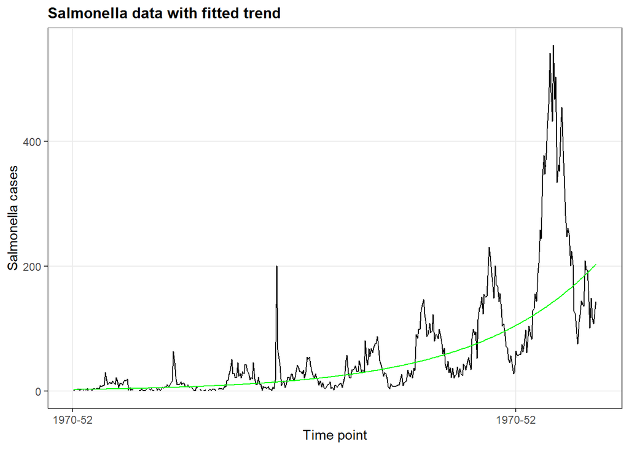

```r
ggplot(data = salmoz2, mapping = aes(x = date)) +
  geom_line(mapping = aes(y = cases)) +
  geom_line(mapping = aes(y = trend), colour = "green") +
  scale_x_yearweek(date_labels = "%Y-%W", date_breaks = "1 year") +
  scale_y_continuous(limits = c(0, NA)) +
  labs(
    x = "Time point",
    y = "Salmonella cases",
    title = "Salmonella data with fitted trend"
  ) +
  tsa_theme
```

Compare the results with those you would have got if you had used linear regression on the original data.

Alternatively, you can run a Poisson or a negative binomial regression to model the data:

```r
salmopoismodel <- glm(cases ~ date, data = salmoz2, family = "poisson")
summary(salmopoismodel)
```

```
##
## Call:
## glm(formula = cases ~ date, family = "poisson", data = salmoz2)
##
## Coefficients:
##              Estimate Std. Error z value Pr(>|z|)
## (Intercept) 1.310e+00  2.483e-02   52.76   <2e-16 ***
## date        1.000e-02  7.118e-05  140.55   <2e-16 ***
## ---
## Signif. codes:  0 '***' 0.001 '**' 0.01 '*' 0.05 '.' 0.1 ' ' 1
##
## (Dispersion parameter for poisson family taken to be 1)
##
##     Null deviance: 40792  on 418  degrees of freedom
## Residual deviance: 12557  on 417  degrees of freedom
##   (12 observations deleted due to missingness)
## AIC: 14688
##
## Number of Fisher Scoring iterations: 5
```

There is more on using Poisson regression later on.

```r
fitted_pois2_df <-
  enframe(fitted(salmopoismodel), name = "date", value = "trend2") %>%
  mutate(date = as.integer(date))

salmoz2 <-
  salmoz2 %>%
  left_join(
    x = .,
    y = fitted_pois2_df,
    by = "date"
  ) %>%
  mutate(trend2 = imputeTS::na_interpolation(x = trend2, option = "linear"))
```

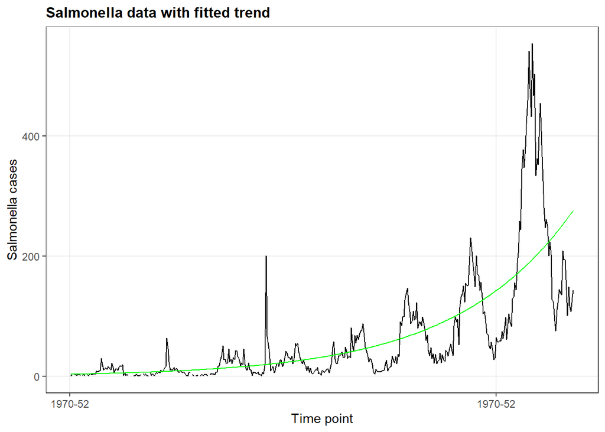

```r
ggplot(data = salmoz2, mapping = aes(x = date)) +
  geom_line(mapping = aes(y = cases)) +
  geom_line(mapping = aes(y = trend2), colour = "green") +
  scale_x_yearweek(date_labels = "%Y-%W", date_breaks = "1 year") +
  scale_y_continuous(limits = c(0, NA)) +
  labs(
    x = "Time point",
    y = "Salmonella cases",
    title = "Salmonella data with fitted trend"
  ) +
  tsa_theme
```